# lm, ivreg, plm, clustering

Andrew P Blake

October 2020

> *Disclaimer: The Bank of England does not accept any liability for misleading or inaccurate information or omissions in the information provided. The subject matter reflects the views of the individual presenter and not the wider Bank of England or its Policy Committees.*

## Libraries

A short tour of available standard econometric methods. There are many more….

```r
library(tidyverse)   # Tidy packages
library(tidymodels)
library(lubridate)

library(plm)         # Panel econometrics package
library(AER)         # Applied Econometrics in R
library(wooldridge)  # Data
```

## Simple regression

The `rental` data are described as

> Wooldridge Source: David Harvey, a former MSU undergraduate, collected the data for 64 “college towns” from the 1980 and 1990 United States censuses.

These are going to be terrible regressions…. A quick look at some of the data:

```r
data("rental")

knitr::kable(head(rental[,1:8], 6),
             caption="rental data: first six rows, indexes, first 6 columns",
             format="html") %>%
  kableExtra::kable_styling(full_width = F)
```

| city | year | pop | enroll | rent | rnthsg | tothsg | avginc |
| --- | --- | --- | --- | --- | --- | --- | --- |
| 1 | 80 | 75211 | 15303 | 197 | 13475 | 26167 | 11537 |
| 1 | 90 | 77759 | 18017 | 342 | 15660 | 29467 | 19568 |
| 2 | 80 | 106743 | 22462 | 323 | 14580 | 37277 | 19841 |
| 2 | 90 | 141865 | 29769 | 496 | 26895 | 55540 | 31885 |
| 3 | 80 | 36608 | 11847 | 216 | 7026 | 13482 | 11455 |
| 3 | 90 | 42099 | 10265 | 351 | 9557 | 16894 | 21202 |

Set up the equation to estimate so we can re-use it later:

```r
rent.eq <- formula("log(rent) ~ y90 + log(pop) + log(avginc) + pctstu")
```

and estimate using `lm`:

```r
rent.lm <- lm(rent.eq,  data=rental)
```

What do the results look like?

```r
print(rent.lm)
```

```
##
## Call:
## lm(formula = rent.eq, data = rental)
##
## Coefficients:
## (Intercept)          y90     log(pop)  log(avginc)       pctstu
##   -0.568806     0.262227     0.040686     0.571446     0.005044
```

```r
summary(rent.lm)
```

```
##
## Call:
## lm(formula = rent.eq, data = rental)
##
## Residuals:
##      Min       1Q   Median       3Q      Max
## -0.24233 -0.07824 -0.01642  0.04389  0.48082
##
## Coefficients:
##              Estimate Std. Error t value Pr(>|t|)
## (Intercept) -0.568806   0.534881  -1.063   0.2897
## y90          0.262227   0.034763   7.543 8.78e-12 ***
## log(pop)     0.040686   0.022515   1.807   0.0732 .
## log(avginc)  0.571446   0.053098  10.762  < 2e-16 ***
## pctstu       0.005044   0.001019   4.949 2.40e-06 ***
## ---
## Signif. codes:  0 '***' 0.001 '**' 0.01 '*' 0.05 '.' 0.1 ' ' 1
##
## Residual standard error: 0.1259 on 123 degrees of freedom
## Multiple R-squared:  0.8613, Adjusted R-squared:  0.8568
## F-statistic: 190.9 on 4 and 123 DF,  p-value: < 2.2e-16
```

Standard enough looking output.

## Panel regressions

Panel estimates are simple. We just specify which model. I’ve slipped in a `glm` estimate too.

```r
prental   <- pdata.frame(rental, index=c("city","year")) # Identifiers

rent.pool <- plm(rent.eq, data=prental, model="pooling")
rent.glm  <- glm(rent.eq, data=prental, family="gaussian")
rent.wit  <- plm(rent.eq, data=prental, model="within")
rent.ran  <- plm(rent.eq, data=prental, model="random")
```

Compare the estimates:

```r
print(rent.lm)
```

```
##
## Call:
## lm(formula = rent.eq, data = rental)
##
## Coefficients:
## (Intercept)          y90     log(pop)  log(avginc)       pctstu
##   -0.568806     0.262227     0.040686     0.571446     0.005044
```

```r
print(rent.pool)
```

```
##
## Model Formula: log(rent) ~ y90 + log(pop) + log(avginc) + pctstu
##
## Coefficients:
## (Intercept)         y90    log(pop) log(avginc)      pctstu
##  -0.5688064   0.2622267   0.0406863   0.5714460   0.0050436
```

```r
print(rent.glm)
```

```
##
## Call:  glm(formula = rent.eq, family = "gaussian", data = prental)
##
## Coefficients:
## (Intercept)          y90     log(pop)  log(avginc)       pctstu
##   -0.568806     0.262227     0.040686     0.571446     0.005044
##
## Degrees of Freedom: 127 Total (i.e. Null);  123 Residual
## Null Deviance:       14.06
## Residual Deviance: 1.95  AIC: -160.3
```

```r
print(rent.wit)
```

```
##
## Model Formula: log(rent) ~ y90 + log(pop) + log(avginc) + pctstu
##
## Coefficients:
##         y90    log(pop) log(avginc)      pctstu
##    0.385521    0.072246    0.309960    0.011203
```

```r
print(rent.ran)
```

```
##
## Model Formula: log(rent) ~ y90 + log(pop) + log(avginc) + pctstu
##
## Coefficients:
## (Intercept)         y90    log(pop) log(avginc)      pctstu
##   0.4451214   0.3233674   0.0561725   0.4468825   0.0051397
```

## Clustering

We can do clustered standard errors in a number of ways. Here’s one:

```r
# Loading the required libraries
library(lmtest)
library(multiwayvcov)
# Clustered standard errors - Fixed effect regression (group)
coeftest(rent.pool, vcov=vcovHC(rent.pool, type="sss", cluster="group"))
```

```
##
## t test of coefficients:
##
##               Estimate Std. Error t value  Pr(>|t|)
## (Intercept) -0.5688064  1.0398553 -0.5470  0.585366
## y90          0.2622267  0.0642476  4.0815 7.991e-05 ***
## log(pop)     0.0406863  0.0288226  1.4116  0.160589
## log(avginc)  0.5714460  0.1229035  4.6496 8.439e-06 ***
## pctstu       0.0050436  0.0015268  3.3033  0.001252 **
## ---
## Signif. codes:  0 '***' 0.001 '**' 0.01 '*' 0.05 '.' 0.1 ' ' 1
```

```r
# Clustered standard errors - Fixed effect regression (group)
coeftest(rent.wit, vcov=vcovHC(rent.wit, type="sss", cluster="group"))
```

```
##
## t test of coefficients:
##
##              Estimate Std. Error t value  Pr(>|t|)
## y90         0.3855214  0.0481161  8.0123 4.669e-11 ***
## log(pop)    0.0722457  0.0688180  1.0498 0.2980164
## log(avginc) 0.3099605  0.0882055  3.5141 0.0008460 ***
## pctstu      0.0112033  0.0028997  3.8636 0.0002767 ***
## ---
## Signif. codes:  0 '***' 0.001 '**' 0.01 '*' 0.05 '.' 0.1 ' ' 1
```

## IV estimation

Another Wooldridge data set:

> Wooldridge Source: These data were obtained by James Heakins, a former MSU undergraduate, for a term project. They come from Botswana’s 1988 Demographic and Health Survey.

Simple model of fertility prediction, needing IV.

```r
data("fertil2")

children.eq    <- as.formula("children ~ educ + age + agesq")
children.eqiv  <- as.formula("children ~ educ + age + agesq | . - educ + frsthalf")
children.eqiv2 <- as.formula("children ~ educ + age + agesq + electric + tv + bicycle | . - educ + frsthalf")

children.lm    <- lm(children.eq,       data=fertil2)
children.iv    <- ivreg(children.eqiv,  data=fertil2)
children.iv2   <- ivreg(children.eqiv2, data=fertil2)

summary(children.lm)
```

```
##
## Call:
## lm(formula = children.eq, data = fertil2)
##
## Residuals:
##     Min      1Q  Median      3Q     Max
## -5.8351 -0.7135 -0.0054  0.7141  7.5055
##
## Coefficients:
##               Estimate Std. Error t value Pr(>|t|)
## (Intercept) -4.1383066  0.2405942 -17.200   <2e-16 ***
## educ        -0.0905755  0.0059207 -15.298   <2e-16 ***
## age          0.3324486  0.0165495  20.088   <2e-16 ***
## agesq       -0.0026308  0.0002726  -9.651   <2e-16 ***
## ---
## Signif. codes:  0 '***' 0.001 '**' 0.01 '*' 0.05 '.' 0.1 ' ' 1
##
## Residual standard error: 1.46 on 4357 degrees of freedom
## Multiple R-squared:  0.5687, Adjusted R-squared:  0.5684
## F-statistic:  1915 on 3 and 4357 DF,  p-value: < 2.2e-16
```

```r
summary(children.iv)
```

```
##
## Call:
## ivreg(formula = children.eqiv, data = fertil2)
##
## Residuals:
##      Min       1Q   Median       3Q      Max
## -6.05272 -0.71481  0.06224  0.76236  7.23693
##
## Coefficients:
##               Estimate Std. Error t value Pr(>|t|)
## (Intercept) -3.3878054  0.5481502  -6.180 6.98e-10 ***
## educ        -0.1714989  0.0531796  -3.225  0.00127 **
## age          0.3236052  0.0178596  18.119  < 2e-16 ***
## agesq       -0.0026723  0.0002797  -9.555  < 2e-16 ***
## ---
## Signif. codes:  0 '***' 0.001 '**' 0.01 '*' 0.05 '.' 0.1 ' ' 1
##
## Residual standard error: 1.491 on 4357 degrees of freedom
## Multiple R-Squared: 0.5502,  Adjusted R-squared: 0.5499
## Wald test:  1765 on 3 and 4357 DF,  p-value: < 2.2e-16
```

```r
summary(children.iv2)
```

```
##
## Call:
## ivreg(formula = children.eqiv2, data = fertil2)
##
## Residuals:
##     Min      1Q  Median      3Q     Max
## -5.9519 -0.7184  0.0290  0.7384  7.3372
##
## Coefficients:
##               Estimate Std. Error t value Pr(>|t|)
## (Intercept) -3.5913324  0.6450889  -5.567 2.74e-08 ***
## educ        -0.1639814  0.0655269  -2.503   0.0124 *
## age          0.3281451  0.0190587  17.218  < 2e-16 ***
## agesq       -0.0027222  0.0002766  -9.843  < 2e-16 ***
## electric    -0.1065314  0.1659650  -0.642   0.5210
## tv          -0.0025550  0.2092301  -0.012   0.9903
## bicycle      0.3320724  0.0515264   6.445 1.28e-10 ***
## ---
## Signif. codes:  0 '***' 0.001 '**' 0.01 '*' 0.05 '.' 0.1 ' ' 1
##
## Residual standard error: 1.479 on 4349 degrees of freedom
## Multiple R-Squared: 0.5577,  Adjusted R-squared: 0.5571
## Wald test: 921.7 on 6 and 4349 DF,  p-value: < 2.2e-16
```

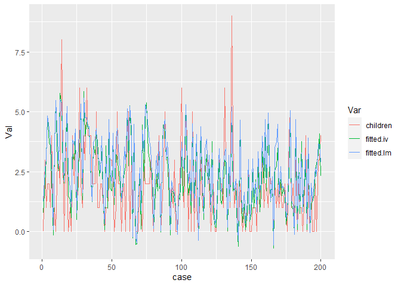

```r
fertil2 %>%
  select(children) %>%
  mutate(fitted.lm = fitted(children.lm)) %>%
  mutate(fitted.iv = fitted(children.iv)) %>%
  mutate(case = 1:nrow(fertil2)) %>%
  filter(case<201) %>%
  pivot_longer(cols=-case, names_to="Var", values_to="Val") %>%
  ggplot() +
  geom_line(aes(x=case,y=Val,group=Var,color=Var))
```

## Some asides

### Using `tidymodels`

We can go about this the long way round too. The `tidymodels` framework suggests we do it like this where we use `parsnip`[^1]

```r
# Parsnip
pars_lm <- linear_reg() %>%
  set_engine("lm") %>%
  set_mode("regression")

pars_lm_fit <- pars_lm %>%
  fit(rent.eq, data=rental)

print(pars_lm_fit, digits=5)
```

```
## parsnip model object
##
## Fit time:  11ms
##
## Call:
## stats::lm(formula = log(rent) ~ y90 + log(pop) + log(avginc) +
##     pctstu, data = data)
##
## Coefficients:
## (Intercept)          y90     log(pop)  log(avginc)       pctstu
##  -0.5688064    0.2622267    0.0406863    0.5714460    0.0050436
```

### Pooled Bayesian regression in Stan

Now we do it all again, but Bayesian and using Stan as the computational engine. Because it is Bayesian, we need some priors, and Stan can provide some semi-automatic ones through available `rstanarm` functions.[^2] The functions below set values recognized by Stan that are scaled by the unconditional variance of the individual regressors. These are from the `rstanarm` package, and see [here](http://mc-stan.org/rstanarm/articles/priors.html) for more information.

```r
# Bayes version: set the prior distributions using rstanarm
prior_t    <- rstanarm::student_t(df = 1)
prior_norm <- rstanarm::normal(scale = 0.25)
prior_aux  <- rstanarm::exponential(1, autoscale = TRUE)
```

Stan wants priors for the coefficients in groups. The priors for the intercept and slope parameters are set as `prior_intercept` and `prior` respectively. The final prior for the variance is set by `prior_aux`, as it is different for different models. If you have the same type of prior for each group, you just have to specify one prior. Don’t worry this doesn’t give the same prior for each if you use the auto scaling capabilities, but in general you might want to supply a specific prior for each coefficient, perhaps with a random walk in mind.

```r
set.seed(123) # Make it replicable

# Make the parsnip model, this time with stan
bayes_mod <-
  linear_reg() %>%
  set_engine("stan",
             iter = 10000,
             prior_intercept = prior_norm,
             prior = prior_t,
             prior_aux = prior_aux)

# Fit the model
bayes_fit <- bayes_mod %>%
  fit(rent.eq, data=rental)

# Regression-type output
print(bayes_fit,   digits=5)
```

```
## parsnip model object
##
## Fit time:  1m 5.9s
## stan_glm
##  family:       gaussian [identity]
##  formula:      log(rent) ~ y90 + log(pop) + log(avginc) + pctstu
##  observations: 128
##  predictors:   5
## ------
##             Median   MAD_SD
## (Intercept) -0.57526  0.54329
## y90          0.26242  0.03464
## log(pop)     0.04129  0.02259
## log(avginc)  0.57042  0.05348
## pctstu       0.00505  0.00104
##
## Auxiliary parameter(s):
##       Median  MAD_SD
## sigma 0.12715 0.00831
##
## ------
## * For help interpreting the printed output see ?print.stanreg
## * For info on the priors used see ?prior_summary.stanreg
```

One of the cool things about this is that it uses Hamiltonian Monte Carlo, and the No-U-Turn Sampler. We can, of course, look at the output from the HMC. All the fitted values are stored in the estimation object as `stanfit` so we can create the kind of graphs we are used to. In `rstan` there is an `extract` function to retrieve the chains, by default stacked one on top of each other.

```r
sfit   <- bayes_fit$fit$stanfit
ex_fit <- rstan::extract(sfit)
print(names(ex_fit))
```

```
## [1] "alpha"    "beta"     "aux"      "mean_PPD" "lp__"
```

[output not shown]

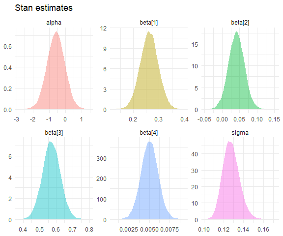

```r
ex_fit$beta %>%
  as_tibble(.name_repair = "unique") %>%
  rename_all( ~ paste0("beta[", 1:ncol(ex_fit$beta), "]")) %>%
  mutate(alpha = ex_fit$alpha, sigma = ex_fit$aux) %>%
  pivot_longer(cols = starts_with(c("bet", "alp", "sig")),
               names_to = "coef",
               values_to = "vals" ) %>%
  ggplot() +
  geom_density(aes(x=vals, group=coef, fill=coef), color=NA, alpha=.44) +
  facet_wrap( ~ coef, scales = "free") +
  theme_minimal() +
  theme(legend.position = "none") +
  labs(x=NULL, y=NULL, title="Stan estimates")
```

[^1]: Don’t ask.
[^2]: There is a certain oddness about using these functions as they are from a package designed to simplify the use of Stan for users of other packages, but hey.